# Introduction to the benthos-package

#### Infaunal Trophic Index (ITI)

The infaunal trophic index (ITI) is calculated as:
$$\mathrm{ITI} = 100 \sum_{i=1}^3 \frac{(4-i)}{3} p_i$$
where $p_i$ is the proportion of species in class $i$, where

- class 1 are suspension feeders (highest quality);
- class 2 are interface feeders;
- class 3 are surface deposit feeders and
- class 4 are subsurface deposit feeders (lowest quality).

See Gittenberger & van Loon (2013) for more information.

We can estimate the ITI by means of:

```r
d %>%
    iti(taxon = TAXON, count = COUNT)
[1] 22.82051
```

The accuracy of the ITI depends (among other things) on the number of taxa for which a sensitivity group is available. The `has_iti` function indicates if a group has been assigned to a taxa or not: Taxa *with* an ITI sensitivity group are

```r
d %>%
    mutate(HAS_GROUP = has_iti(taxon = TAXON))
# A tibble: 41 × 3
   TAXON                  COUNT HAS_GROUP
   <chr>                  <dbl> <lgl>
 1 Angulus tenuis             1 TRUE
 2 Aphelochaeta marioni       1 TRUE
 3 Aphelochaeta marioni      25 TRUE
 4 Bathyporeia                2 TRUE
 5 Capitella capitata         2 TRUE
 6 Cossura longocirrata       1 TRUE
 7 Echinocardium cordatum     1 TRUE
 8 Ensis                      1 TRUE
 9 Lanice conchilega          4 TRUE
10 Magelona johnstoni         2 TRUE
# ℹ 31 more rows
```

The percentage of the total abundance *without* an ITI group is given below

```r
d %>%
    mutate(HAS_GROUP = has_iti(taxon = TAXON)) %>%
    summarise(percentage = 100 * sum(COUNT[!HAS_GROUP]) / sum(COUNT)) %>%
    as.numeric
[1] 0.7633588
```

## Calculating multiple biodiversity measures in one go

Multiple measures of biodiversity for a specified grouping of the data can be computed for all sampling units by means of:

```r
oosterschelde %>%
    group_by(HABITAT, YEAR, POOLRUN, POOLID) %>%
    summarise(
        N = total_abundance(count = COUNT),
        S = species_richness(taxon = TAXON, count = COUNT),
        D = margalef(taxon = TAXON, count = COUNT),
        SN = rygg(taxon = TAXON, count = COUNT),
        SNa = rygg(taxon = TAXON, count = COUNT, adjusted = TRUE),
        H = shannon(taxon = TAXON, count = COUNT)
    )
`summarise()` has grouped output by 'HABITAT', 'YEAR', 'POOLRUN'. You can override using the
`.groups` argument.
# A tibble: 569 × 10
# Groups:   HABITAT, YEAR, POOLRUN [60]
   HABITAT               YEAR  POOLRUN POOLID     N     S     D    SN   SNa     H
   <chr>                 <chr>   <int>  <int> <dbl> <int> <dbl> <dbl> <dbl> <dbl>
 1 Polyhaline-Intertidal 2010        1      1   519    24  3.68  1.73  1.60  2.41
 2 Polyhaline-Intertidal 2010        1      2   616    41  6.23  2.00  1.85  3.64
 3 Polyhaline-Intertidal 2010        1      3   370    21  3.38  1.71  1.57  2.67
 4 Polyhaline-Intertidal 2010        1      4   283    27  4.61  1.90  1.74  3.58
 5 Polyhaline-Intertidal 2010        1      5   515    31  4.80  1.87  1.73  2.79
 6 Polyhaline-Intertidal 2010        1      6   368    28  4.57  1.88  1.72  3.45
 7 Polyhaline-Intertidal 2010        1      7   595    28  4.23  1.80  1.67  3.16
 8 Polyhaline-Intertidal 2010        2      1   500    25  3.86  1.76  1.63  2.66
 9 Polyhaline-Intertidal 2010        2      2   413    25  3.98  1.79  1.65  3.33
10 Polyhaline-Intertidal 2010        2      3   394    29  4.69  1.88  1.73  3.83
# ℹ 559 more rows
```

or more concise:

```r
oosterschelde %>%
    group_by(HABITAT, YEAR, POOLRUN, POOLID) %>%
    summarise(
        N = total_abundance(., COUNT),
        S = species_richness(., TAXON, COUNT),
        D = margalef(., TAXON, COUNT),
        SN = rygg(., TAXON, COUNT),
        SNa = rygg(., TAXON, COUNT, adjusted = TRUE),
        H = shannon(., TAXON, COUNT)
    )
`summarise()` has grouped output by 'HABITAT', 'YEAR', 'POOLRUN'. You can override using the
`.groups` argument.
# A tibble: 569 × 10
# Groups:   HABITAT, YEAR, POOLRUN [60]
   HABITAT               YEAR  POOLRUN POOLID     N     S     D    SN   SNa     H
   <chr>                 <chr>   <int>  <int> <dbl> <int> <dbl> <dbl> <dbl> <dbl>
 1 Polyhaline-Intertidal 2010        1      1   519    24  3.68  1.73  1.60  2.41
 2 Polyhaline-Intertidal 2010        1      2   616    41  6.23  2.00  1.85  3.64
 3 Polyhaline-Intertidal 2010        1      3   370    21  3.38  1.71  1.57  2.67
 4 Polyhaline-Intertidal 2010        1      4   283    27  4.61  1.90  1.74  3.58
 5 Polyhaline-Intertidal 2010        1      5   515    31  4.80  1.87  1.73  2.79
 6 Polyhaline-Intertidal 2010        1      6   368    28  4.57  1.88  1.72  3.45
 7 Polyhaline-Intertidal 2010        1      7   595    28  4.23  1.80  1.67  3.16
 8 Polyhaline-Intertidal 2010        2      1   500    25  3.86  1.76  1.63  2.66
 9 Polyhaline-Intertidal 2010        2      2   413    25  3.98  1.79  1.65  3.33
10 Polyhaline-Intertidal 2010        2      3   394    29  4.69  1.88  1.73  3.83
# ℹ 559 more rows
```

## Advanced topics

### Number of pool runs and species richness

In the previous section we used $10$ pool runs. But is this sufficient to stabilize the results? In this section we will demonstrate the effect of pooling on the average species richness. We will reuse large sections of the code given earlier in this document:

```r
oosterschelde <- oosterschelde_orig
n_pool_runs <- 100
pool_runs <- replicate(
    n = n_pool_runs, {
    oosterschelde %>%
        group_by(HABITAT, YEAR) %>%
        mutate(
            POOLID = pool(
                sample_id = ID,
                area = AREA,
                target_area = c(0.09, 0.11)
            )
        ) %>%
        ungroup %>%
        select(POOLID)
    }
)
names(pool_runs) <- paste0("POOLRUN", 1:n_pool_runs)

d <- pool_runs %>%
    as_tibble %>%
    bind_cols(oosterschelde) %>%
    as_tibble %>%
    gather(key = "POOLRUN", value = "POOLID", starts_with("POOLRUN")) %>%
    mutate(POOLRUN = parse_number(POOLRUN) %>% as.integer) %>%
    filter(!is.na(POOLID)) %>%
    select(POOLRUN, POOLID, HABITAT, AREA, YEAR, ID, TAXON, COUNT) %>%
    group_by(HABITAT, YEAR, POOLRUN, POOLID) %>%
    summarise(S = species_richness(taxon = TAXON, count = COUNT)) %>%
    group_by(HABITAT, YEAR, POOLRUN) %>%
    summarise(S = mean(S)) %>%
    mutate(S_rm = cummean(S))
`summarise()` has grouped output by 'HABITAT', 'YEAR', 'POOLRUN'. You can override using the
`.groups` argument.
`summarise()` has grouped output by 'HABITAT', 'YEAR'. You can override using the `.groups`
argument.
d
# A tibble: 600 × 5
# Groups:   HABITAT, YEAR [6]
   HABITAT               YEAR  POOLRUN     S  S_rm
   <chr>                 <chr>   <int> <dbl> <dbl>
 1 Polyhaline-Intertidal 2010        1  29.4  29.4
 2 Polyhaline-Intertidal 2010        2  29.9  29.6
 3 Polyhaline-Intertidal 2010        3  27    28.8
 4 Polyhaline-Intertidal 2010        4  27.9  28.5
 5 Polyhaline-Intertidal 2010        5  28.6  28.5
 6 Polyhaline-Intertidal 2010        6  27.6  28.4
 7 Polyhaline-Intertidal 2010        7  28.7  28.4
 8 Polyhaline-Intertidal 2010        8  27.4  28.3
 9 Polyhaline-Intertidal 2010        9  27.7  28.2
10 Polyhaline-Intertidal 2010       10  28.9  28.3
# ℹ 590 more rows
```

The results are given in the figure below. The blue dots give the species richness for each pool-run for each year and habitat. The red line is the running mean species richness. In general, it stabilizes quickly.

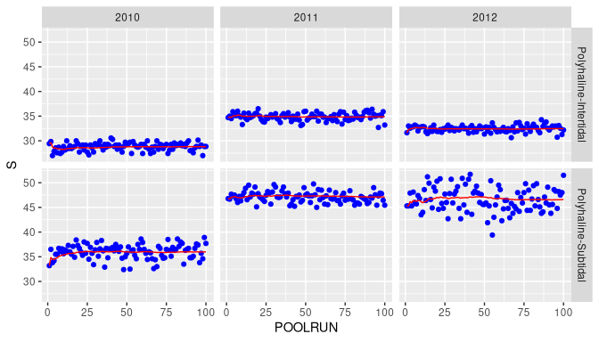

## References

Borja, A., J. Franco and V. Perez (2000). A Marine Biotic Index to Establish the Ecological Quality of Soft-Bottom Benthos Within European Estuarine and Coastal Environments. Marine Pollution Bulletin 40: 1100-1114

Gittenberger A. and W. van Loon, (2013). Sensitivities of marine macrozoobenthos to environmental pressures in the Netherlands. Nederlandse Faunistische Mededelingen 41: 79-112.

Hill, M.O., 1973. Diversity and Evenness: A Unifying Notation and Its Consequences. Ecology 54:427-432

Hurlbert, S.H., 1971. The Nonconcept of Species Diversity: A Critique and Alternative Parameters. Ecology 52:577-586.

Milton Bache, S. and H. Wickham (2014). magrittr: A Forward-Pipe Operator for R. R package version 1.5. https://CRAN.R-project.org/package=magrittr

Peet, R. K. 1974, The Measurement of Species Diversity. Annual Review of Ecology and Systematics 5:285-307.

R Core Team (2017). R: A language and environment for statistical computing. R Foundation for Statistical Computing, Vienna, Austria. URL https://www.R-project.org/.

Rygg, B. (2006). Developing indices for quality-status classification of marine soft-bottom fauna in Norway. Norwegian Institute for Water Research, Oslo, Norway. NIVA Report SNO 5208-2006.

Van Loon, W.M.G.M. A.R. Boon, A. Gittenberger, D.J.J. Walvoort, M. Lavaleye, G.C.A. Duineveld, A.J. Verschoor, 2015. Application of the Benthic Ecosystem Quality Index 2 to benthos in Dutch transitional and coastal waters. Journal of Sea Research 103:1-13.

Wickham, H. (2014). Tidy data. The Journal of Statistical Software, vol. 59, 2014.

Wickham, H. (2017). tidyr: Easily Tidy Data with spread() and gather() Functions. R package version 0.7.2. https://CRAN.R-project.org/package=tidyr

Wickham, H. R. Francois, L. Henry and K. Müller (2017). dplyr: A Grammar of Data Manipulation. R package version 0.7.4. https://CRAN.R-project.org/package=dplyr